# 1. Introdução a Simulação e Modelação Computacional em Engenharia Física

## 1.1 Objectivos da UC

- Introdução à simulação e modelação de sistemas físicos
- Análise crítica e comparação com sistemas reais dos resultados obtidos.

## 1.2 Matérias a abordar

- Breve introdução aos conceitos de simulação
- Introdução ao Pyhton, Numpy e Matplotlib
- Simulação de ciclos de crescimento e fogo em florestas
- Simulações de Monte Carlo de passeios aleatórios simples, não reversíveis, crescentes e crescentes que se auto-evitam.
- Ferromagnetismo: Introdução, Modelo de Heisenberg, Modelo de Weiss, Teoria de Landau, Simulações de Monte Carlo com o modelo de Ising;
- Equações diferenciais - métodos numéricos.
- Optimização do código.

## 1.3 Avaliação

- Frequência à cadeira é obtida com presença obrigatória a 2/3 das aulas.
- Avaliação por 2 trabalhos computacionais entre os propostos pelo docente e efectuado em grupo com nota até 9 valores cada.
- Nota sumativa de participação nas aulas e em discussões.

## 1.4 Ferramentas a usar

- Python 3.6 ou superior
- Biblioteca Numpy e Matplotlib
- Outras bibliotecas poderão ser usadas ao longo das aulas.
- É aconselhado a utilização de uma IDE.

Sugere-se a instalação do pacote **[Anaconda Distribution](https://www.anaconda.com/products/distribution)** que já instala maior parte das bibliotecas necessárias e a IDE Spyder entre outras ferramentas.

# 2 Introdução ao Python

- Python é uma linguagem de programação **interpretada** em oposição a **compilada**. Este facto permite um ciclo de desenvolvimento mais rápido em que se pode testar uma única parte do código de forma rápida sem se ter que compilar o programa todo.
- É também uma linguagem com possibilidade de usar-se programação orientada a objectos.
- Tem de raiz estruturas de dados avançadas (List, Dictionary, Tuple, Set).
- É uma linguagem dinamicamente tipificada, ou seja as variáveis têm um tipo de dados mas pode-se alterar o tipo de dados para que a variável aponta.

## 2.1 Cálculo simples

```python
2 + 2
```

```
4
```

```python
2 * 3.
```

```
6.0
```

```python
2 ** 6
```

```
64
```

```python
4 / 3
```

```
1.3333333333333333
```

```python
4 // 3
```

```
1
```

## 2.2 Variáveis

```python
a = 3
b = 6.
a / b
```

```
0.5
```

```python
a = 7.96
b = 666
a / b
```

```
0.011951951951951952
```

```python
a = "Hello "
b = "world!"
a + b
```

```
'Hello world!'
```

## 2.3 Estruturas de dados

**List** Uma coleção de dados possível de aceder por índice. Pode conter dados de vários tipos e pode ser alterada.

```python
a = [1, 2, "Hello World!", [1, 3]]
a[0]
```

```
1
```

```python
a[2]
```

```
'Hello World!'
```

```python
a[-1]
```

```
[1, 3]
```

```python
a[1:3]
```

```
[2, 'Hello World!']
```

```python
a = a + [3, 4]
a
```

```
[1, 2, 'Hello World!', [1, 3], 3, 4]
```

```python
a[4] = "Replacing 3 for this text"
a
```

```
[1, 2, 'Hello World!', [1, 3], 'Replacing 3 for this text', 4]
```

**CUIDADO** As variáveis são referências para um dado bloco de memória que contém a informação. Quando se igualam duas variáveis e os dados na memória são mutáveis (lists, dictionaries, sets, objects) e se altera o valor em memória essa alteração é reflectida em todas as variáveis que apontam para o mesmo local de memória!

```python
b = a
b
```

```
[1, 2, 'Hello World!', [1, 3], 'Replacing 3 for this text', 4]
```

```python
b[-1] = 111
b
```

```
[1, 2, 'Hello World!', [1, 3], 'Replacing 3 for this text', 111]
```

```python
a
```

```
[1, 2, 'Hello World!', [1, 3], 'Replacing 3 for this text', 111]
```

É possível saber se duas variáveis apontam para o mesmo objecto (*is*) ou se dois objectos são idênticos (*==*)

```python
a is b
```

```
True
```

```python
c = [1, 2, 'Hello World!', [1, 3], 'Replacing 3 for this text', 111]
```

```python
a is c
```

```
False
```

```python
a == c
```

```
True
```

É possível criar listas por *compreension*:

```python
a = [1, 2, 3]
b = [x ** 2 for x in a]
b
```

```
[1, 4, 9]
```

**Tuples** São como as listas mas são imutáveis, não se pode acrescentar valores nem alterar os mesmos. Excepção caso um dos elementos do tuple seja mutável este pode ser alterado.

```python
a = (1, 2, 3)
a
```

```
(1, 2, 3)
```

```python
a[-1]
```

```
3
```

```python
a[:2]
```

```
(1, 2)
```

```python
a[1] = 5
```

```
---------------------------------------------------------------------------
TypeError                                 Traceback (most recent call last)
Cell In[26], line 1
----> 1 a[1] = 5

TypeError: 'tuple' object does not support item assignment
```

```python
a = (1, 3 , [3, 1, 4])
a
```

```
(1, 3, [3, 1, 4])
```

```python
a[1] = 10
```

```
---------------------------------------------------------------------------
TypeError                                 Traceback (most recent call last)
Cell In[28], line 1
----> 1 a[1] = 10

TypeError: 'tuple' object does not support item assignment
```

```python
a[2].append(10)
a
```

```
(1, 3, [3, 1, 4, 10])
```

```python
a[2][2] = 66
a
```

```
(1, 3, [3, 1, 66, 10])
```

**Set** Estrutura não ordenada em que todos os elementos são diferentes

```python
set1 = {1, 3, 5, "ola"}
set1
```

```
{1, 3, 5, 'ola'}
```

```python
2 in set1
```

```
False
```

```python
"ola" in set1
```

```
True
```

```python
set1.add("mundo")
set1
```

```
{1, 3, 5, 'mundo', 'ola'}
```

```python
set1.discard(5)
set1
```

```
{1, 3, 'mundo', 'ola'}
```

```python
set2 = {1, 5, 6, "hello", 999}
set2
```

```
{1, 5, 6, 999, 'hello'}
```

```python
set1.union(set2)
```

```
{1, 3, 5, 6, 999, 'hello', 'mundo', 'ola'}
```

```python
set1.intersection(set2)
```

```
{1}
```

**Dictionary** Estrutura não ordenada com elementos do tipo chave + valor. Estrutura optimizada para procuras pela chave.

```python
dic = {1:"ola", 2:"mundo", "ola":5, "mundo":99}
dic
```

```
{1: 'ola', 2: 'mundo', 'ola': 5, 'mundo': 99}
```

```python
dic["mundo"]
```

```
99
```

```python
dic.keys()
```

```
dict_keys([1, 2, 'ola', 'mundo'])
```

```python
dic.values()
```

```
dict_values(['ola', 'mundo', 5, 99])
```

```python
dic["ola"] = 1/5
dic
```

```
{1: 'ola', 2: 'mundo', 'ola': 0.2, 'mundo': 99}
```

```python
dic["novo"] = "velho"
dic
```

```
{1: 'ola', 2: 'mundo', 'ola': 0.2, 'mundo': 99, 'novo': 'velho'}
```

```python
'novo' in dic
```

```
True
```

```python
'velho' in dic
```

```
False
```

```python
dic.pop('mundo')
dic
```

```
{1: 'ola', 2: 'mundo', 'ola': 0.2, 'novo': 'velho'}
```

## 2.4 Condições

```python
x = 5

if x > 10 and x < 5:
    print('One')
    print('two')
elif x < 10 or x > 6:
    print('Three')
else:
    print('four')
```

```
Three
```

```python
print('true') if 'ola' == 'olá' else print('false')
```

```
false
```

## 2.5 Ciclos

Os ciclos em Python são principalmente **for** e **while**.

```python
aList = range(2, 28) #range gera uma sequência de números até e excluindo o valor dado. Também se pode indicar início e passo
for elem in aList:
    for n in range(2, elem):
        if elem % n == 0:
            print(elem, ' equals', n, ' x ', elem // n)
            break
    else:
        print(elem, ' is prime')
```

```
2  is prime
3  is prime
4  equals 2  x  2
5  is prime
6  equals 2  x  3
7  is prime
8  equals 2  x  4
9  equals 3  x  3
10  equals 2  x  5
11  is prime
12  equals 2  x  6
13  is prime
14  equals 2  x  7
15  equals 3  x  5
16  equals 2  x  8
17  is prime
18  equals 2  x  9
19  is prime
20  equals 2  x  10
21  equals 3  x  7
22  equals 2  x  11
23  is prime
24  equals 2  x  12
25  equals 5  x  5
26  equals 2  x  13
27  equals 3  x  9
```

```python
number = 2
while number < 28:
    div = 2
    while div < number:
        if number % div == 0:
            print(number, ' equals', div, ' x ', number // div)
            break
        div += 1
    else:
        print(number, ' is prime')
    number += 1
```

```
2  is prime
3  is prime
4  equals 2  x  2
5  is prime
6  equals 2  x  3
7  is prime
8  equals 2  x  4
9  equals 3  x  3
10  equals 2  x  5
11  is prime
12  equals 2  x  6
13  is prime
14  equals 2  x  7
15  equals 3  x  5
16  equals 2  x  8
17  is prime
18  equals 2  x  9
19  is prime
20  equals 2  x  10
21  equals 3  x  7
22  equals 2  x  11
23  is prime
24  equals 2  x  12
25  equals 5  x  5
26  equals 2  x  13
27  equals 3  x  9
```

O *else* tanto no *for* como no *while* são opcionais

## 2.6 Funções

```python
def aFunction(x, y, opt1 = True, opt2 = 'sum'):
    if opt1 and opt2 == 'sum':
        return x + y
    elif opt1 and opt2 == "sub":
        return x - y
    elif opt1 and opt2 == 'div':
        return y / x
    else:
        print('No result')
```

```python
aFunction(2, 5)
```

```
7
```

```python
aFunction(2, 5, False)
```

```
No result
```

```python
aFunction(2, 5, opt2 = 'sub')
```

```
-3
```

## 2.7 Classes

```python
class AnObject:
    '''A dumy object for demonstrating classes in Python'''

    def __init__(self, number, string):
        self.number = number
        self.string = string

    def getNumber(self):
        return self.number

    def getString(self):
        return self.string

    def setNmber(self, number):
        self.number = number

    def setString(self, string):
        self.string = string

    def addToString(self, aString):
        self.string = self.string + " " + aString
```

```python
a = AnObject(15, 'Hello')
c = AnObject(5, 'AAA')
```

```python
a.getNumber()
```

```
15
```

```python
a.addToString('World!')
a.getString()
```

```
'Hello World!'
```

```python
a.string
```

```
'Hello World!'
```

```python
help(a)
```

```
Help on AnObject in module __main__ object:

class AnObject(builtins.object)
 |  AnObject(number, string)
 |  A dumy object for demonstrating classes in Python
 |  Methods defined here:
 |  __init__(self, number, string)
 |      Initialize self.  See help(type(self)) for accurate signature.
 |  addToString(self, aString)
 |  getNumber(self)
 |  getString(self)
 |  setNmber(self, number)
 |  setString(self, string)
 |  ----------------------------------------------------------------------
 |  Data descriptors defined here:
 |  __dict__
 |      dictionary for instance variables
 |  __weakref__
 |      list of weak references to the object
```

```python
type(5)
```

```
int
```

# 3 Numpy

**Numpy** é uma biblioteca dedicada a calculo numérico, no seu centro encontra-se os **arrays** que ao contrário das **list** em Python apenas podem conter elementos do mesmo tipo. O uso de funções e objectos da biblioteca **Numpy** permite calculo numérico mais eficiente.  
**[Numpy](https://numpy.org/)**

```python
import numpy as np
array1 = np.array([1, 2., 3])
array1
```

```
array([1., 2., 3.])
```

```python
type(array1)
```

```
numpy.ndarray
```

```python
array1 = np.array([1, 2, 3], dtype = float)
array1
```

```
array([1., 2., 3.])
```

```python
array2 = 3 * array1
array2
```

```
array([3., 6., 9.])
```

```python
array1 + array2
```

```
array([ 4.,  8., 12.])
```

```python
np.cross(array1, array2 + [0, 0, 1])
```

```
array([ 2., -1.,  0.])
```

```python
np.dot(array1, array2)
```

```
42.0
```

```python
matrix = np.arange(1, 10)
matrix
```

```
array([1, 2, 3, 4, 5, 6, 7, 8, 9])
```

```python
matrix = matrix.reshape(3, 3)
matrix
```

```
array([[1, 2, 3],
       [4, 5, 6],
       [7, 8, 9]])
```

```python
np.linalg.det(matrix)
```

```
0.0
```

```python
np.zeros((4,2))
```

```
array([[0., 0.],
       [0., 0.],
       [0., 0.],
       [0., 0.]])
```

```python
np.ones((5,2))
```

```
array([[1., 1.],
       [1., 1.],
       [1., 1.],
       [1., 1.],
       [1., 1.]])
```

```python
np.empty((1,5))
```

```
array([[4.63794491e-310, 0.00000000e+000, 4.63907037e-310,
        4.63907017e-310, 0.00000000e+000]])
```

```python
np.random.rand(4,3)
```

```
array([[0.41297717, 0.58340362, 0.54946028],
       [0.05291996, 0.05591455, 0.77670499],
       [0.42191101, 0.0854561 , 0.05160676],
       [0.23059988, 0.58170653, 0.61324664]])
```

# 4. Matplotlib - Gráficos

**Matplotlib** é a biblioteca de python especializada em gráficos.  
**[matplotlib](https://matplotlib.org/)**

Tem como base vários elementos:

- Figure: A área onde se vai desenhar gráficos e todos os outros elementos
- Axes: Aquilo a que normalmente chamamos o gráfico propriamente dito. Não confundir com Axis

Todos os outros elementos que posam constituir o gráfico ou figuras, eixos (Axis), legenda, título, descrição dos eixos, anotações, etc.

```python
import matplotlib.pyplot as plt
```

```python
x = np.linspace(0, 10, 100)
linear = 2 * x + 5
quadratic = x ** 2 - 2 * x + 5
```

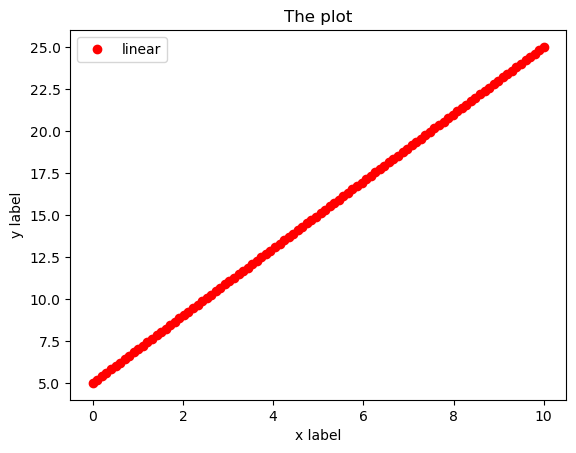

```python
fig, ax = plt.subplots() #Cria a figura e o Axes

ax.plot(x, linear, 'ro', label = 'linear') #Acrescenta uma série ao gráfico
ax.set_xlabel('x label') #Define a legenda do eixo horizontal
ax.set_ylabel('y label') #Define a legenda do eixo vertical
ax.set_title('The plot') #Define o título
ax.legend() #Acrescenta a legenda
#fig.show() #Dependendo do ambiente onde se está a correr o programa pode ser necessário usar para a figura ser visível
```

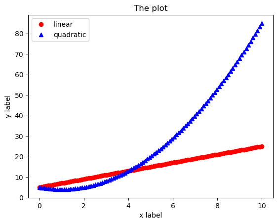

```python
ax.plot(x, quadratic, 'b^', label = 'quadratic')
ax.legend()
fig
```